# Lab 6

Collin Dabbieri

10/7/2019

# Task 1

```r
options(warn=-1)
getwd()
```

```
## [1] "/home/collindabbieri/Documents/AppliedRegressionAnalysis/Labs/Lab6"
```

# Task 2

```r
library(readxl)

kwhrs=read_excel("../../Dataxls/Excel/KWHRS.xls")
head(kwhrs)
```

```
## # A tibble: 6 x 3
##    SIZE  SIZESQ USAGE
##   <dbl>   <dbl> <dbl>
## 1  1290 1664100  1182
## 2  1350 1822500  1172
## 3  1470 2160900  1264
## 4  1600 2560000  1493
## 5  1710 2924100  1571
## 6  1840 3385600  1711
```

## a)

Construct a scatterplot for the data. Is there evidence to support the use of a quadratic model?

$$y=\beta_0+\beta_1x+\beta_2x^2$$

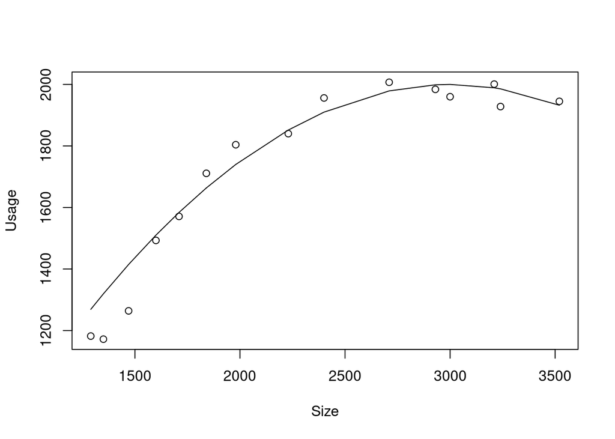

```r
beta0=-250
beta1=1.5
beta2=-0.00025
x=kwhrs$SIZE
y=kwhrs$USAGE
yfit=beta0+beta1*x+beta2*x^2
plot(x,y,type='p',xlab="Size",ylab="Usage")
lines(x,yfit)
```

This data looks like it would be well represented by a quadratic model.

## b)

Use the method of least-squares to estimate the unknown parameters $\beta_0,\beta_1, \beta_2$ in the quadratic model

```r
model=lm(USAGE~SIZE+SIZESQ,data=kwhrs)
summary(model)
```

```
##
## Call:
## lm(formula = USAGE ~ SIZE + SIZESQ, data = kwhrs)
##
## Residuals:
##    Min     1Q Median     3Q    Max
## -77.20 -40.90  15.79  28.71  65.05
##
## Coefficients:
##               Estimate Std. Error t value Pr(>|t|)
## (Intercept) -8.067e+02  1.669e+02  -4.834 0.000409 ***
## SIZE         1.962e+00  1.525e-01  12.861 2.23e-08 ***
## SIZESQ      -3.404e-04  3.212e-05 -10.599 1.90e-07 ***
## ---
## Signif. codes:  0 '***' 0.001 '**' 0.01 '*' 0.05 '.' 0.1 ' ' 1
##
## Residual standard error: 50.2 on 12 degrees of freedom
## Multiple R-squared:  0.9773, Adjusted R-squared:  0.9735
## F-statistic: 258.1 on 2 and 12 DF,  p-value: 1.375e-10
```

$\hat{\beta_0}=-8.067*10^{2}$ $\hat{\beta_1}=1.962$ $\hat{\beta_2}=-3.404*10^{-4}$

## c)

Graph the prediction equation and assess how well the model fits the data, both visually and numerically

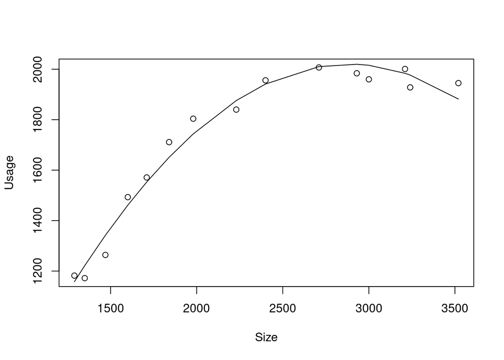

```r
beta0=-8.067e2
beta1=1.962e0
beta2=-3.404e-4
x=kwhrs$SIZE
y=kwhrs$USAGE
yfit=beta0+beta1*x+beta2*x^2
plot(x,y,type='p',xlab="Size",ylab="Usage")
lines(x,yfit)
```

Visually, the model fits the data very well. Numerically, the adjusted $R^2$ value of 0.9735 also tells us the model fits the data very well.

## d)

Interpret the $\beta$ estimates

The estimate for $\beta_0$ can only be interpreted within the range of the data. The fact that $\beta_0$ is less than zero means that there are positive square foot values that will have negative predictions for usage. This is nonsensical, so the predicted y values should only be considered for valid size values.

The negative sign on $\beta_2$ tells us that the fit is concave down. Meaning usage levels off for higher size values.

## e)

Is the overall model useful (at $\alpha=0.01$) for predicting electrical usage y?

Yes, the p-value from the F-test is <0.01, so the model is adequate at the 99% confidence level.

## f)

Is there sufficient evidence of concave downward curvature in the electrical usage-home size relationship? Test using $\alpha=0.01$

The two-tailed p-value of the T test for $\beta_2$ is significantly less than 0.01. Meaning we have evidence for downward concavity at the 99% confidence level.

# Task 3

How do you check to see if a population variance is likely constant?

Plot residuals vs. $\hat{y}$ if the variance is constant you would expect the residual values to be centered at 0 and have the same spread throughout.

Read in the CLERICAL data set and using the model y~x1+…+x5 recreate the plots shown on pg. 608.

```r
clerical=read_excel("../../Dataxls/Excel/CLERICAL.XLS")

head(clerical)
```

```
## # A tibble: 6 x 10
##     Obs Day   `Y-Hours` `X1-Mail` `X2-Gifts` `X3-Charge` `X4-Returns`
##   <dbl> <chr>     <dbl>     <dbl>      <dbl>       <dbl>        <dbl>
## 1     1 M          128.      7781        100         886          235
## 2     2 T          114.      7004        110         962          388
## 3     3 W          147.      7267         61        1342          398
## 4     4 Th         124.      2129        102        1153          457
## 5     5 F          100.      4878         45         803          577
## 6     6 S          119.      3999        144        1127          345
## # … with 3 more variables: `X5-Checks` <dbl>, `X6-Misc` <dbl>,
## #   `X7-Tickets` <dbl>
```

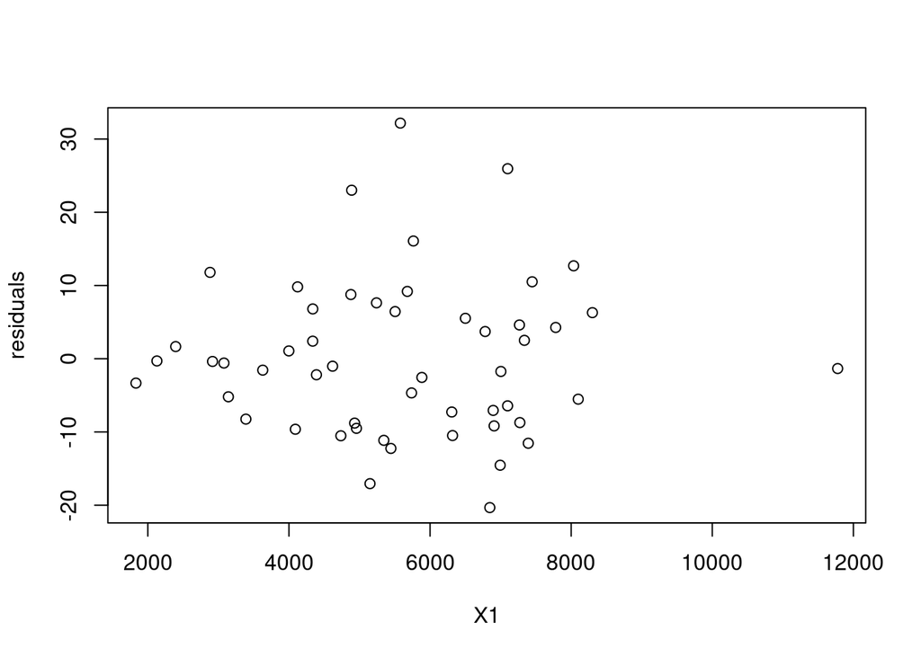

```r
Y=clerical$`Y-Hours`
X1=clerical$`X1-Mail`
X2=clerical$`X2-Gifts`
X3=clerical$`X3-Charge`
X4=clerical$`X4-Returns`
X5=clerical$`X5-Checks`

model=lm(Y~X1+X2+X3+X4+X5)
r=model$residuals
fit=model$fitted.values
n=length(Y)
k=5
SSE=sum(r^2)
s=sqrt(SSE/(n-(k+1)))




plot(X1,r,type="p",xlab="X1",ylab="residuals")
```

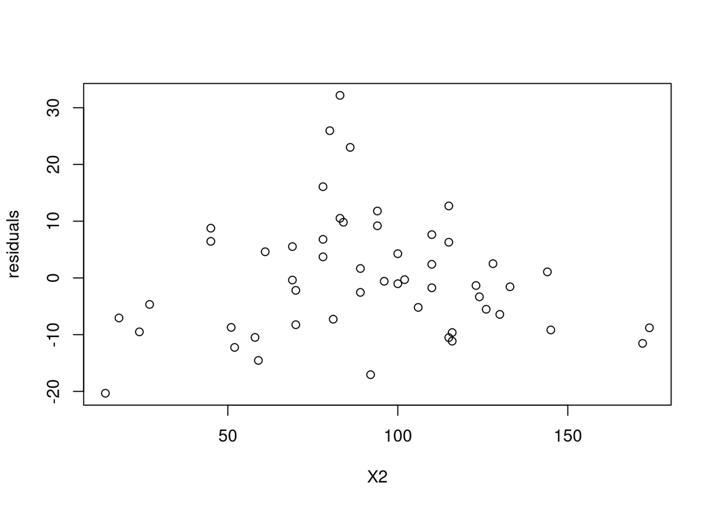

```r
plot(X2,r,type="p",xlab="X2",ylab="residuals")
```

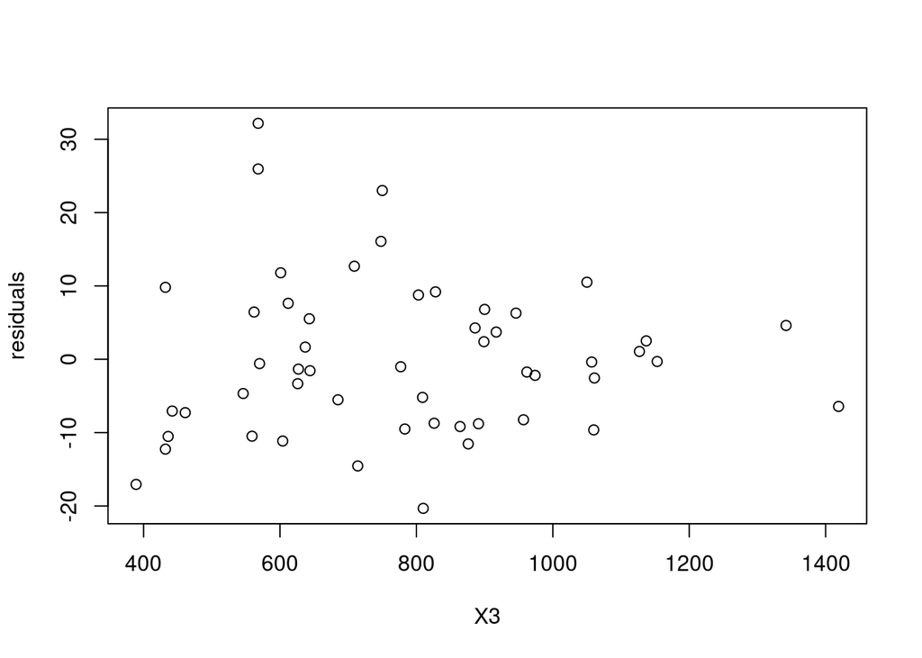

```r
plot(X3,r,type="p",xlab="X3",ylab="residuals")
```

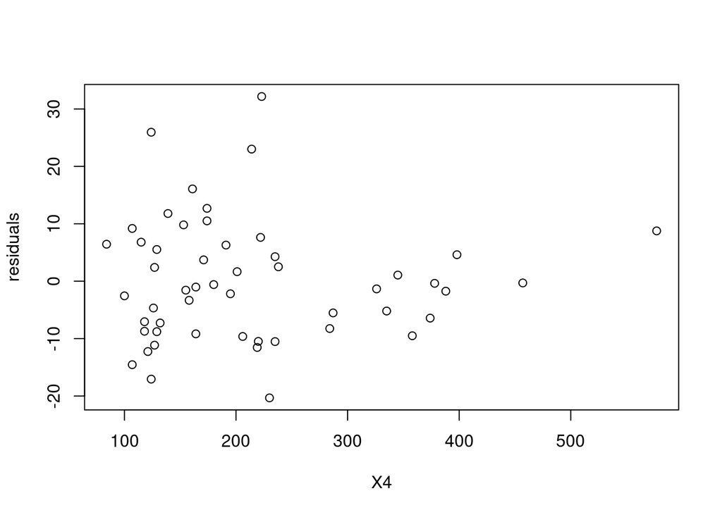

```r
plot(X4,r,type="p",xlab="X4",ylab="residuals")
```

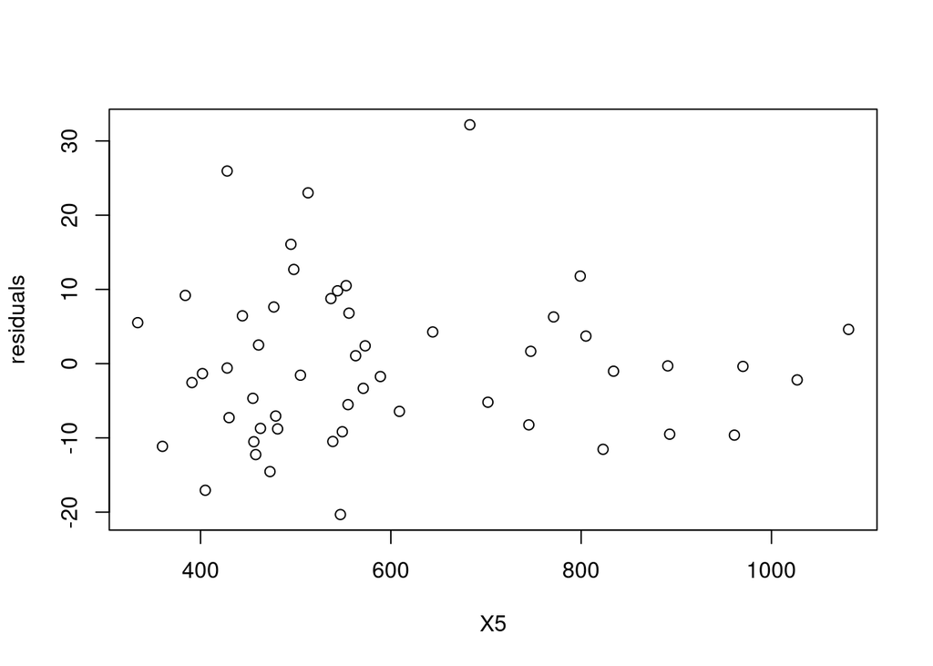

```r
plot(X5,r,type="p",xlab="X5",ylab="residuals")
```

What do they say? What do you conclude?

```r
tab=matrix(,nrow=52,ncol=7)
tab[,1]=clerical$Obs
tab[,2]=clerical$`X1-Mail`
tab[,3]=clerical$`Y-Hours`
tab[,4]=fit
tab[,5]=fit/s
tab[,6]=r
tab[,7]=(Y-fit)/(s)

colnames(tab)=c("Obs","X1-Mail","Y-Hours","Fit","SE Fit","Residual","St Resid")
tab
```

```
##       Obs X1-Mail Y-Hours      Fit    SE Fit    Residual    St Resid
##  [1,]   1    7781   128.5 124.2260 11.124551   4.2740445  0.38274471
##  [2,]   2    7004   113.6 115.3346 10.328321  -1.7345930 -0.15533444
##  [3,]   3    7267   146.6 141.9838 12.714783   4.6162032  0.41338534
##  [4,]   4    2129   124.3 124.5995 11.158006  -0.2995361 -0.02682374
##  [5,]   5    4878   100.4  91.6322  8.205749   8.7678039  0.78516510
##  [6,]   6    3999   119.2 118.1294 10.578600   1.0705840  0.09587180
##  [7,]   7   11777   109.5 110.8356  9.925430  -1.3355730 -0.11960182
##  [8,]   8    5764   128.5 112.4209 10.067397  16.0791064  1.43989913
##  [9,]   9    7392   131.2 142.7352 12.782069 -11.5351663 -1.03298500
## [10,]  10    8100   112.2 117.7196 10.541897  -5.5195537 -0.49428124
## [11,]  11    4736    95.4 105.9150  9.484788 -10.5149964 -0.94162783
## [12,]  12    4337   124.6 122.1975 10.942902   2.4024956  0.21514574
## [13,]  13    3079   103.7 104.2861  9.338922  -0.5861386 -0.05248926
## [14,]  14    7273   103.6 112.3162 10.058019  -8.7161697 -0.78054120
```

[output cut: 38 more lines]

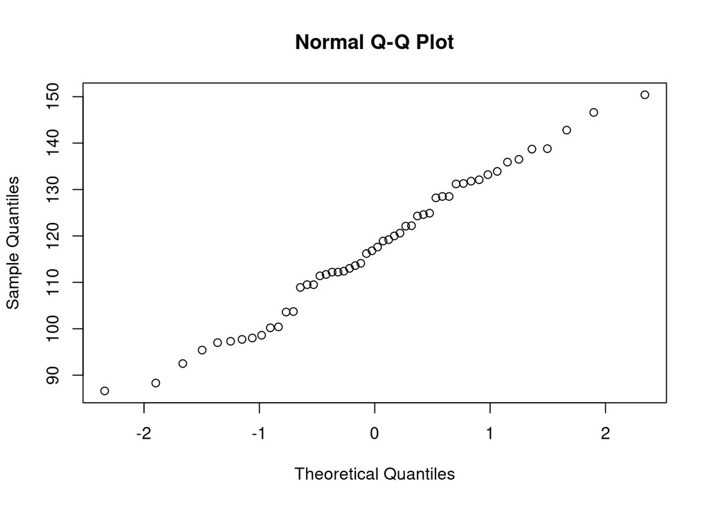

```r
qqnorm(Y)
```

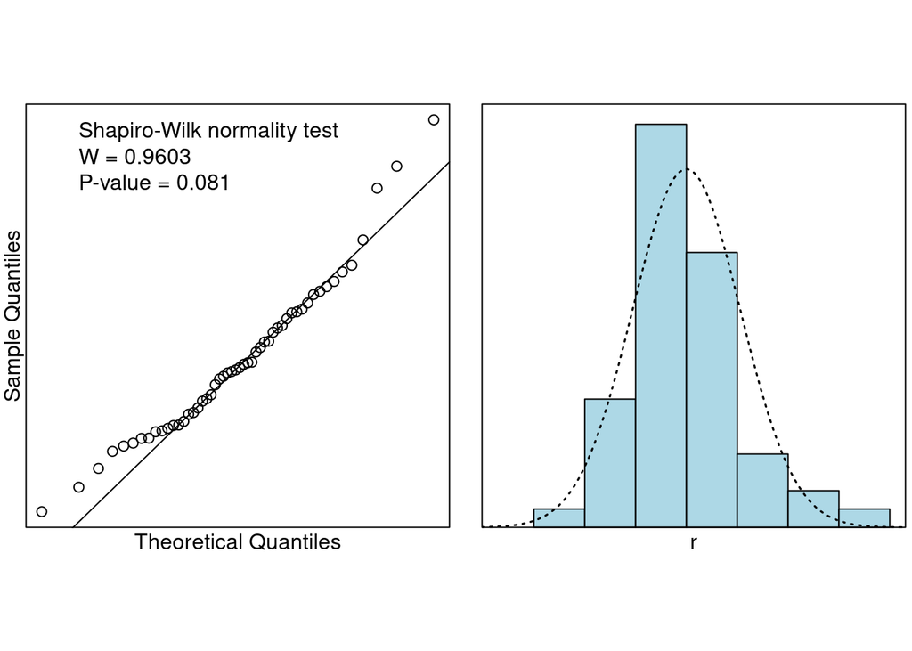

```r
library(s20x)

normcheck(r,shapiro.wilk = TRUE)
```

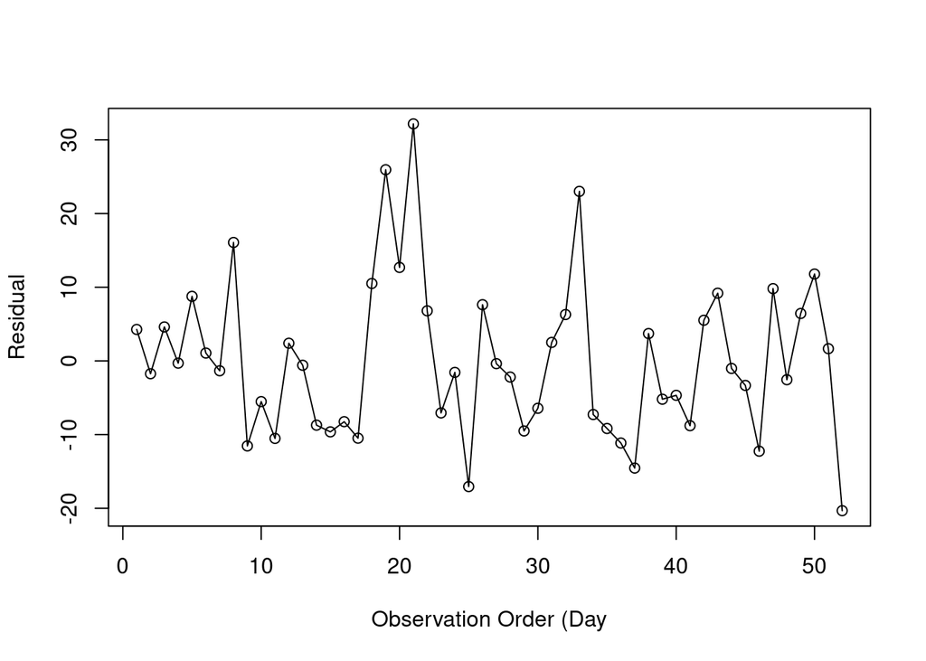

```r
x=clerical$Obs
plot(x,r,type='p',xlab="Observation Order (Day",ylab="Residual")
lines(x,r)
```

# Task 4

For the Jack-Knife procedure, unusually large deleted residuals are those values with absolute value greater than some multiple of s

```r
#X can be a matrix where ncols is n and nrows is number of variables
myinfluential=function(X,Y){
  deleted_resid=c()
  high_deleted_resid=c()
  k=ncol(X)
  n=nrow(X)
  model_all=lm(Y~X)
  r=model_all$residuals
  SSE=sum(r^2)
  s=sqrt(SSE/(n-(k+1)))

  for(i in 1:n){
    y_val=Y[i]
    X_trim=X[-i,]
    Y_trim=Y[-i]
    model=lm(Y_trim~X_trim)

    x_pred=X[i,]

    coeff=model$coefficients


    y_pred=coeff[1]+coeff[2]*x_pred[1]+coeff[3]*x_pred[2]+coeff[4]*x_pred[3]+coeff[5]*x_pred[4]+coeff[6]*x_pred[5]
    names(y_pred)=""

    if(abs(y_val-y_pred)>3*s){
      high_deleted_resid=append(high_deleted_resid,TRUE)

    } else{
      high_deleted_resid=append(high_deleted_resid,FALSE)
    }




    deleted_resid=append(deleted_resid,y_val-y_pred)

  }

  final=matrix(,nrow=n,ncol=2)
  final[,1]=deleted_resid
  final[,2]=high_deleted_resid
  colnames(final)=c("deleted_residual","large_deleted_residual")
  return(list(deleted_resid=data.frame(final)))
}

n=length(Y)
k=5
X=matrix(,nrow=n,ncol=k)
X[,1]=X1
X[,2]=X2
X[,3]=X3
X[,4]=X4
X[,5]=X5

deleted_resid=myinfluential(X,Y)
print(deleted_resid)
```

```
## $deleted_resid
##    deleted_residual large_deleted_residual
## 1         4.5194865                      0
## 2        -1.9260073                      0
## 3         6.1353646                      0
## 4        -0.3713053                      0
## 5        14.6252232                      0
## 6         1.2699996                      0
## 7        -2.0338519                      0
## 8        16.6076517                      0
## 9       -14.8985659                      0
## 10       -6.2569395                      0
## 11      -11.8355411                      0
## 12        2.5779238                      0
## 13       -0.6444222                      0
```

[output cut: 39 more lines]